# Hyperspectral Anomaly Detection on EO Imagery

MLP Autoencoder vs 1D CNN Autoencoder (Pavia University HSI Dataset)

## Objective

This notebook presents anomaly detection in hyperspectral Earth Observation imagery using reconstruction-based models.

We evaluate:

- MLP autoencoder (global spectral modeling)
- 1D CNN autoencoder (local spectral modeling)

Goal: understand how model design affects anomaly detection performance under a controlled setup.

## Workflow

1. Data loading and inspection
2. Image preprocessing
3. Model training (2 architectures)
4. Evaluation and comparison (OA, F1, IoU, and ROC AUC)
5. Prediction visualization

## Dataset

We use a **subset of the Pavia University hyperspectral image dataset**.

- hyperspectral urban scene
- 610 × 340 pixels, 103 spectral bands
- ground truth with multiple land-cover classes

The dataset is not originally designed for anomaly detection; anomalies are defined from selected ground-truth classes.

Training and testing regions are spatially separated.

## Data Inspection

Visual inspection to verify class distribution, spatial structure, and ground truth coverage.

```python
import torch
print("PyTorch:", torch.__version__)
```

```
PyTorch: 2.10.0+cu126
```

```python
import os, random, requests, scipy.io
import numpy as np
import pandas as pd
import matplotlib.pyplot as plt
from pathlib import Path
from sklearn.metrics import roc_auc_score, average_precision_score, confusion_matrix, f1_score

import torch
import torch.nn as nn
import torch.optim as optim
from torch.utils.data import DataLoader, Dataset

SEED = 42
random.seed(SEED); np.random.seed(SEED); torch.manual_seed(SEED)
device = torch.device('cuda' if torch.cuda.is_available() else 'cpu')
print("Using device:", device)
```

```
Using device: cuda
```

```python
# Load Pavia University HSI dataset
DATA_ROOT = Path("./data/paviaU")
DATA_ROOT.mkdir(parents=True, exist_ok=True)

urls = {
    "data": "http://www.ehu.eus/ccwintco/uploads/e/ee/PaviaU.mat",
    "gt": "http://www.ehu.eus/ccwintco/uploads/5/50/PaviaU_gt.mat"
}

for key, url in urls.items():
    out = DATA_ROOT / f"{key}.mat"
    if not out.exists():
        r = requests.get(url)
        with open(out, 'wb') as f:
            f.write(r.content)
        print("Downloaded", out)

data = scipy.io.loadmat(DATA_ROOT/"data.mat")["paviaU"]
gt   = scipy.io.loadmat(DATA_ROOT/"gt.mat")["paviaU_gt"]
print("Data shape:", data.shape, "GT shape:", gt.shape)
```

```
Data shape: (610, 340, 103) GT shape: (610, 340)
```

```python
# Build class table
labels, counts = np.unique(gt[gt > 0], return_counts=True)

order = np.argsort(labels)
labels = labels[order]
counts = counts[order]

class_names = {
    1: "Asphalt",
    2: "Meadows",
    3: "Gravel",
    4: "Trees",
    5: "Painted metal sheets",
    6: "Bare Soil",
    7: "Bitumen",
    8: "Self-Blocking Bricks",
    9: "Shadows",
}

class_table = pd.DataFrame({
    "Label": labels,
    "Class": [class_names[int(i)] for i in labels],
    "Pixels (px)": counts
})

class_table["Ratio (%)"] = 100 * class_table["Pixels (px)"] / class_table["Pixels (px)"].sum()
class_table["Ratio (%)"] = class_table["Ratio (%)"].round(2)
```

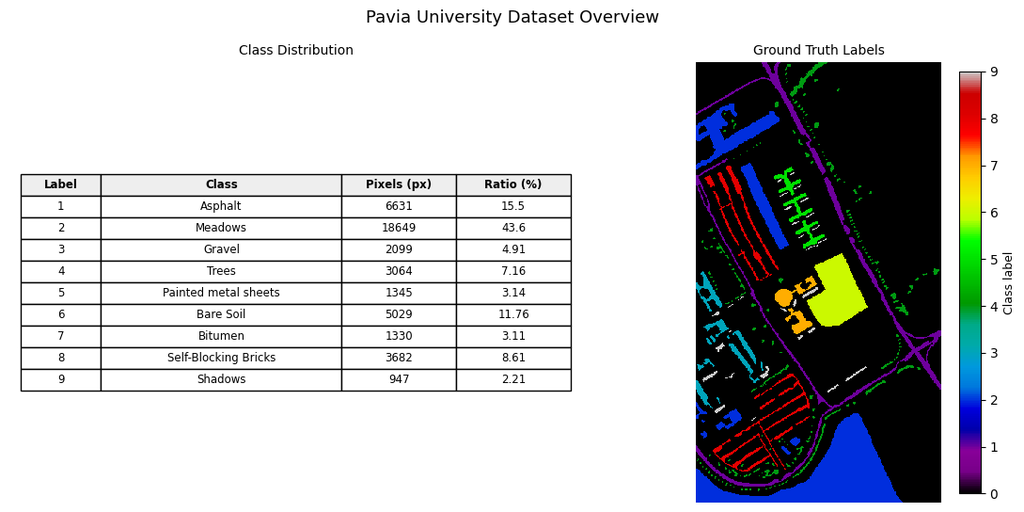

```python
# Overview
fig, axes = plt.subplots(
    1, 2,
    figsize=(11, 5.5),
    gridspec_kw={"width_ratios": [1.25, 1]}
)

# Left: class table
axes[0].axis("off")

table = axes[0].table(
    cellText=class_table.values,
    colLabels=class_table.columns,
    loc="center",
    cellLoc="center",
    colWidths=[0.14, 0.42, 0.20, 0.20]
)

table.auto_set_font_size(False)
table.set_fontsize(8.5)
table.scale(1.0, 1.25)

for (row, col), cell in table.get_celld().items():
    if row == 0:
        cell.set_text_props(weight="bold")
        cell.set_facecolor("#eeeeee")

axes[0].set_title("Class Distribution", fontsize=10)

# Right: ground truth plot
im = axes[1].imshow(gt, cmap="nipy_spectral", interpolation="nearest")
axes[1].set_title("Ground Truth Labels", fontsize=10)
axes[1].axis("off")

cbar = fig.colorbar(im, ax=axes[1], fraction=0.046, pad=0.04)
cbar.set_label("Class label", fontsize=9)

fig.suptitle("Pavia University Dataset Overview", fontsize=13)

plt.tight_layout()
plt.show()
```

## Image Preprocessing

- Spectral bands are normalized independently to reduce scale differences across channels.
- The anomaly target is defined from the ground-truth label map: Class 5 = Painted metal sheets.
- A normal-only training region and an anomaly-containing test region are selected manually to simulate unsupervised anomaly detection.

```
======== Region Summary ========
Full image  : (610, 340, 103)
Train region: (60, 80, 103)   | anomaly pixels: 0
Test region : (130, 90, 103)  | anomaly pixels: 1345
```

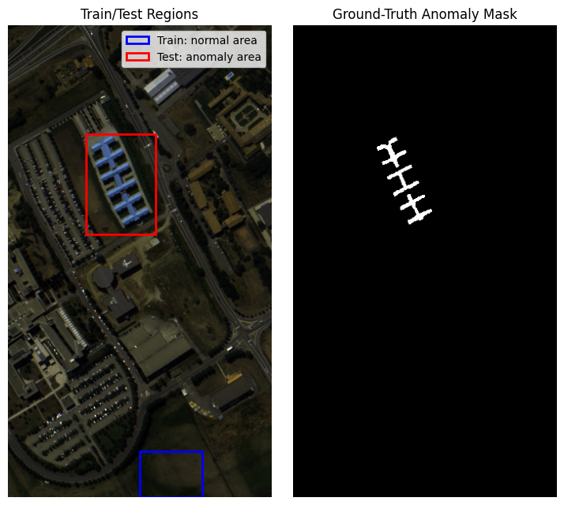

```python
# Normalize data per band
h, w, c = data.shape
X = data.reshape(-1, c).astype(np.float32)
band_min = X.min(axis=0)
band_max = X.max(axis=0)
X = (X - band_min) / (band_max - band_min + 1e-6)
data_norm = X.reshape(h, w, c)

# Define anomaly mask
# Class 5 = painted metal sheets
anomaly_class = 5
mask = (gt == anomaly_class).astype(np.uint8)

# Define train/test regions
# Train: normal grass area only
train_region = (slice(550, 610), slice(170, 250))

# Test: metal-sheet target area
test_region = (slice(140, 270), slice(100, 190))

train_data = data_norm[train_region]
test_data  = data_norm[test_region]
test_mask  = mask[test_region]

print("======== Region Summary ========")
print(f"Full image  : {data_norm.shape}")
print(f"Train region: {train_data.shape}   | anomaly pixels: {mask[train_region].sum()}")
print(f"Test region : {test_data.shape}  | anomaly pixels: {test_mask.sum()}")

# Visualize train/test regions
rgb = data_norm[:, :, [55, 41, 12]]

fig, axes = plt.subplots(1, 2, figsize=(7.5, 7.5))
axes[0].imshow(rgb)
axes[0].set_title("Train/Test Regions")
axes[0].axis("off")

for region, color, label in [
    (train_region, "blue", "Train: normal area"),
    (test_region, "red", "Test: anomaly area"),
]:
    y_slice, x_slice = region
    rect = plt.Rectangle(
        (x_slice.start, y_slice.start),
        x_slice.stop - x_slice.start,
        y_slice.stop - y_slice.start,
        edgecolor=color,
        facecolor="none",
        linewidth=2,
        label=label,
    )
    axes[0].add_patch(rect)

axes[0].legend(loc="upper right")

# Ground-truth anomaly mask
axes[1].imshow(mask, cmap="gray")
axes[1].set_title("Ground-Truth Anomaly Mask")
axes[1].axis("off")

plt.tight_layout(pad=2.0)
plt.show()
```

```python
# Train region distribution
train_labels, train_counts = np.unique(gt[train_region], return_counts=True)

train_table = pd.DataFrame({
    "Label": train_labels,
    "Class": [class_names.get(int(i), "Background") for i in train_labels],
    "Pixels (train)": train_counts
})

train_table["Ratio (%)"] = 100 * train_table["Pixels (train)"] / train_table["Pixels (train)"].sum()
train_table["Ratio (%)"] = train_table["Ratio (%)"].round(2)


# Test region distribution
test_labels, test_counts = np.unique(gt[test_region], return_counts=True)

test_table = pd.DataFrame({
    "Label": test_labels,
    "Class": [class_names.get(int(i), "Background") for i in test_labels],
    "Pixels (test)": test_counts
})

test_table["Ratio (%)"] = 100 * test_table["Pixels (test)"] / test_table["Pixels (test)"].sum()
test_table["Ratio (%)"] = test_table["Ratio (%)"].round(2)


train_table = train_table.rename(columns={"Ratio (%)": "Ratio train (%)"})
test_table  = test_table.rename(columns={"Ratio (%)": "Ratio test (%)"})

table = pd.merge(train_table, test_table, on=["Label", "Class"], how="outer").fillna(0)
table["Pixels (train)"] = table["Pixels (train)"].astype(int)
table["Pixels (test)"]  = table["Pixels (test)"].astype(int)
table.loc[table["Label"] == anomaly_class, "Class"] += " ★"
table = table.sort_values(by="Pixels (test)", ascending=False).reset_index(drop=True)

display(table)
```

|  | Label | Class | Pixels (train) | Ratio train (%) | Pixels (test) | Ratio test (%) |
| --- | --- | --- | --- | --- | --- | --- |
| 0 | 0 | Background | 18 | 0.38 | 8996 | 76.89 |
| 1 | 5 | Painted metal sheets ★ | 0 | 0.00 | 1345 | 11.50 |
| 2 | 2 | Meadows | 4782 | 99.62 | 768 | 6.56 |
| 3 | 1 | Asphalt | 0 | 0.00 | 300 | 2.56 |
| 4 | 9 | Shadows | 0 | 0.00 | 215 | 1.84 |
| 5 | 4 | Trees | 0 | 0.00 | 55 | 0.47 |
| 6 | 8 | Self-Blocking Bricks | 0 | 0.00 | 21 | 0.18 |

```python
# Dataset wrapper for hyperspectral anomaly detection
# - Training: uses only normal-region pixels (no anomaly mask)
# - Testing: uses all pixels with corresponding anomaly labels
class HSIAnomalyDataset(Dataset):
    def __init__(self, X, mask=None, train=True):
        """
        X: (h, w, c) hyperspectral cube (already normalized)
        mask: (h, w) anomaly mask (for test set only)
        train: True for training (only normal pixels), False for testing (all pixels)
        """
        h, w, c = X.shape
        self.X = X.reshape(-1, c)
        self.mask = mask.reshape(-1) if mask is not None else None
        self.train = train

        self.indices = np.arange(len(self.X))

    def __len__(self):
        return len(self.indices)

    def __getitem__(self, idx):
        i = self.indices[idx]
        x = torch.tensor(self.X[i], dtype=torch.float32)
        if self.train:
            return x
        else:
            y = torch.tensor(self.mask[i], dtype=torch.long)
            return x, y

# Construct datasets from spatially cropped train/test regions
train_ds = HSIAnomalyDataset(train_data, train=True)
test_ds  = HSIAnomalyDataset(test_data, mask=test_mask, train=False)

train_loader = DataLoader(train_ds, batch_size=512, shuffle=True)
test_loader  = DataLoader(test_ds, batch_size=2048, shuffle=False)

print(f"Train pixels: {len(train_ds)} | Test pixels: {len(test_ds)} | Anomalies (test): {test_mask.sum()}")
```

```
Train pixels: 4800 | Test pixels: 11700 | Anomalies (test): 1345
```

## Model Training (2 Architectures)

We compare two reconstruction-based autoencoders under the same training and evaluation pipeline:

- MLP Autoencoder: learns global relationships across the full spectral vector.
- 1D CNN Autoencoder: learns local neighboring patterns along the spectral dimension using convolutional filters.

```python
# Autoencoder - MLP
class MLPAE(nn.Module):
    def __init__(self, in_dim):
        super().__init__()
        self.encoder = nn.Sequential(
            nn.Linear(in_dim, 128), nn.ReLU(),
            nn.Linear(128, 32), nn.ReLU()
        )
        self.decoder = nn.Sequential(
            nn.Linear(32, 128), nn.ReLU(),
            nn.Linear(128, in_dim), nn.Sigmoid()
        )

    def forward(self, x):
        return self.decoder(self.encoder(x))

# Autoencoder - 1D CNN
# kernel_size=3 → each filter sees 3 adjacent spectral bands (local context)
class CNNAE(nn.Module):
    def __init__(self, in_dim):
        super().__init__()
        self.encoder = nn.Sequential(
            nn.Conv1d(1, 16, kernel_size=3, padding=1), nn.ReLU(),
            nn.Conv1d(16, 8, kernel_size=3, padding=1), nn.ReLU()
        )
        self.decoder = nn.Sequential(
            nn.Conv1d(8, 16, kernel_size=3, padding=1), nn.ReLU(),
            nn.Conv1d(16, 1, kernel_size=3, padding=1), nn.Sigmoid()
        )

    def forward(self, x):
        x = x.unsqueeze(1)
        z = self.encoder(x)
        out = self.decoder(z)
        return out.squeeze(1)


def build_model(model_name, in_dim):
    if model_name == "mlp":
        return MLPAE(in_dim)
    elif model_name == "cnn1d":
        return CNNAE(in_dim)
    else:
        raise ValueError(f"Unknown model_name: {model_name}")
```

```python
# Unified training setup
model_name = "mlp"   # "mlp" | "cnn1d"

in_dim = train_data.shape[-1] # number of input features (spectral bands)
model = build_model(model_name, in_dim).to(device)

criterion = nn.MSELoss()
optimizer = optim.Adam(model.parameters(), lr=1e-2)

EPOCHS = 50

for epoch in range(EPOCHS):
    model.train()
    epoch_loss = 0.0

    for batch in train_loader:
        batch = batch.to(device)

        out = model(batch)
        loss = criterion(out, batch)

        optimizer.zero_grad()
        loss.backward()
        optimizer.step()

        epoch_loss += loss.item()

    epoch_loss /= len(train_loader)

    if (epoch + 1) % 10 == 0 or epoch == 0 or epoch == EPOCHS - 1:
        print(f"[{model_name.upper()} | Epoch {epoch+1:02d}/{EPOCHS}] Loss: {epoch_loss:.6f}")
```

```
[MLP | Epoch 01/50] Loss: 0.041699
[MLP | Epoch 10/50] Loss: 0.000325
[MLP | Epoch 20/50] Loss: 0.000107
[MLP | Epoch 30/50] Loss: 0.000078
[MLP | Epoch 40/50] Loss: 0.000058
[MLP | Epoch 50/50] Loss: 0.000047
```

## Evaluation

- ROC-AUC / PR-AUC — threshold-independent separability of reconstruction scores (normal vs anomaly)
- F1 (anomaly) — primary metric; reflects detection quality under strong class imbalance
- IoU (normal / anomaly) — spatial overlap; highlights boundary errors and fragmented predictions
- mIoU — overall segmentation consistency across classes
- OA — reported for reference, but not reliable under imbalance

```python
# Final evaluation
model.eval()
scores, labels = [], []

with torch.no_grad():
    for x, y in test_loader:
        x, y = x.to(device), y.to(device)
        out = model(x)
        # reconstruction error per pixel: MSE over spectral bands (C-dimension)
        loss = ((out - x) ** 2).mean(dim=1)
        scores.extend(loss.cpu().numpy())
        labels.extend(y.cpu().numpy())

scores = np.array(scores)
labels = np.array(labels, dtype=np.int64)

# ROC-AUC & PR-AUC
roc_auc = roc_auc_score(labels, scores)
pr_auc  = average_precision_score(labels, scores)

# Select decision threshold that maximizes F1 score
best_f1, best_th = 0, 0.0
for th in np.linspace(scores.min(), scores.max(), 100):
    pred = (scores > th).astype(int)
    f1 = f1_score(labels, pred)
    if f1 > best_f1:
        best_f1, best_th = f1, th

pred = (scores > best_th).astype(int)
cm = confusion_matrix(labels, pred, labels=[0,1])
oa = np.diag(cm).sum()/cm.sum()
iou = np.diag(cm)/(cm.sum(1)+cm.sum(0)-np.diag(cm)+1e-6)

print("======== Evaluation ========")
print(f"ROC-AUC    : {roc_auc:.3f} | PR-AUC : {pr_auc:.3f}")
print()

print(f"OA         : {oa:.3f} | F1     : {best_f1:.3f}")
print(f"IoU        : normal {iou[0]:.3f}, anomaly {iou[1]:.3f}")
print(f"mIoU       : {iou.mean():.3f}")
print()

print(f"Score range: {scores.min():.2e} → {scores.max():.3f}")
print(f"Threshold  : {best_th:.5f}")
print(f"Anomaly px : pred {pred.sum()}, gt {labels.sum()}")
```

```
======== Evaluation ========
ROC-AUC    : 0.975 | PR-AUC : 0.799

OA         : 0.938 | F1     : 0.779
IoU        : normal 0.931, anomaly 0.638
mIoU       : 0.785

Score range: 1.77e-05 → 0.060
Threshold  : 0.01752
Anomaly px : pred 1932, gt 1345
```

## Experimental Notes

- The MLP autoencoder converged quickly; increasing epochs beyond 50 provided negligible gains for both models.
- Adam with a learning rate of 1e-2 performed best; smaller or larger values degraded performance.
- AdamW, SGD, StepLR, and cosine decay did not yield improvements.
- The 1D CNN autoencoder underperformed the MLP, suggesting that global spectral structure is more informative than local spectral patterns in this setup.
- Detection performance is governed by spectral separability from the training distribution; classes with distinct spectral signatures are easier to detect.

## Sensitivity Analysis — Different Ground Truth Classes as Anomalies

We fix the trained model (vegetation-dominated training region) and evaluate sensitivity by redefining the anomaly label: each ground-truth class is treated as the anomaly in turn.

| Class | Name | Pixels (test) | F1 | Interpretation |
| --- | --- | --- | --- | --- |
| 0 | Background | 8996 | 0.87 | heterogeneous composition; strongly deviates from vegetation baseline |
| 5 | Painted metal sheets | 1345 | 0.78 | strong spectral contrast relative to vegetation |
| 2 | Meadows | 768 | 0.12 | spectrally aligned with training distribution |
| 1 | Asphalt | 300 | 0.09 | partial spectral overlap with learned normal features |
| 8 | Self-blocking bricks | 21 | 0.01 | low contrast; high similarity to surrounding materials |

Note — pixel counts refer to the test region; classes with low support yield less reliable F1 estimates.

Performance degrades as class spectra become more aligned with the training distribution.

## Visualization

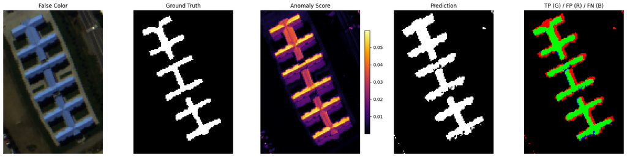

```python
# Prediction visualization on selected test area
h_test, w_test, _ = test_data.shape

score_map = scores.reshape(h_test, w_test)
pred_map  = pred.reshape(h_test, w_test)
gt_map    = test_mask.astype(bool)
pred_bool = pred_map.astype(bool)

# Error overlay
tp = pred_bool & gt_map
fp = pred_bool & ~gt_map
fn = ~pred_bool & gt_map

overlay = np.zeros((*pred_map.shape, 3), dtype=np.uint8)
overlay[tp] = [0, 255, 0] # Green = True Positive
overlay[fp] = [255, 0, 0] # Red = False Positive
overlay[fn] = [0, 0, 255] # Blue = False Negative

fig, axes = plt.subplots(1, 5, figsize=(20, 5))

axes[0].imshow(test_data[:, :, [55, 41, 12]])
axes[0].set_title("False Color")
axes[0].axis("off")

axes[1].imshow(test_mask, cmap="gray")
axes[1].set_title("Ground Truth")
axes[1].axis("off")

im = axes[2].imshow(score_map, cmap="inferno")
axes[2].set_title("Anomaly Score")
axes[2].axis("off")
fig.colorbar(im, ax=axes[2], fraction=0.046, pad=0.04)

axes[3].imshow(pred_map, cmap="gray")
axes[3].set_title("Prediction")
axes[3].axis("off")

axes[4].imshow(overlay)
axes[4].set_title("TP (G) / FP (R) / FN (B)")
axes[4].axis("off")

plt.tight_layout()
plt.show()
```

Model localizes the main anomalous structures reliably; errors concentrate at object boundaries and in small isolated false positives. The anomaly score map clearly highlights the metal-sheet structures, with residual errors arising from boundary ambiguity due to annotation tightness, spectral similarity in surrounding materials, and illumination variation.

## Model Comparison

| Model | Input Modeling | OA | F1 (anom) | IoU (anom) | PR AUC | ROC AUC | Strength | Limitation |
| --- | --- | --- | --- | --- | --- | --- | --- | --- |
| MLP AE | Global (full vector) | 0.94 | 0.78 | 0.64 | 0.80 | 0.98 | Captures full spectral signature | Ignores local continuity |
| 1D CNN AE | Local (kernel=3) | 0.91 | 0.49 | 0.32 | 0.47 | 0.78 | Learns local spectral patterns | Misses long-range spectral dependencies |

Key Observation

- The MLP autoencoder consistently outperforms the 1D CNN autoencoder across F1, IoU (anomaly), and PR AUC. This indicates that anomaly separability is primarily driven by global spectral signature, rather than short-range local correlations.
- The 1D CNN, constrained to local neighborhoods (kernel size = 3, i.e., three adjacent spectral bands), captures smooth spectral variations but fails to model long-range dependencies across the full spectrum, which are critical for distinguishing anomalous materials.

## Conclusion

In this controlled setting, global spectral reconstruction is more effective than local convolutional filtering for anomaly detection. This suggests that anomalies are characterized by holistic spectral deviations rather than localized band-to-band variations.

A simple reconstruction-based autoencoder provides a strong baseline for hyperspectral anomaly detection. In this experiment, tuning the learning rate improved performance more than increasing model complexity. The best result came from the MLP autoencoder, while the 1D CNN did not improve detection.

This suggests that, in this Pavia University anomaly setting, global spectral reconstruction is more effective than local spectral filtering.